# Pixar: Uma história de dados

## Pixar e as lembranças afetivas

Então, você finalmente completou 18 anos. Você está se preparando para ir para a faculdade. Você pode até deixar a casa de seus pais e se mudar para outra cidade. Talvez você leve alguns objetos que o lembrem de suas lembranças de infância. Ou quem sabe, talvez você seja o pai ou a mãe deste novo ser independente. Seu coração dói pelos caminhos que seu filho ou sua filha tomarão. E talvez você esteja se percebendo no Toy Story 3. Você é Andy ou você é o pai de Andy.

Quer você seja um dos pais de Andy ou do próprio Andy, é provável que nos últimos anos você tenha assistido a maioria dos filmes da Pixar. Você deve ter ficado aflito com o desespero de Encontrar Nemo, aprendeu algumas lições de Carros, ficou assustado com o futuro apocalíptico de Wall-e, e assim por diante. Aqui neste texto, a missão é fazer com que você não se sinta sozinho. Perceber que as aventuras contadas na tela do filme são emoções compartilhadas e são muito amadas pelo público e pelos críticos. Vamos ver isso através de dados e gráficos usando as cores da Toy Story, a franquia mais icônica da Pixar. Pegue seus balões de hélio e vamos juntos nesta jornada.

## Orçamento, bilheteria…e crítica

Eu não sou Andy nesta história. Eu sou o pai dele. Meu filho e eu costumávamos ver todos os filmes da Pixar. O primeiro de que me lembro foi Carros. Nós o vimos dezenas de vezes. Talvez por diferentes razões. Do meu lado, eu costumava gostar de ver o Art Deco e o espírito dos anos 50 e 60 que era facilmente reconhecido no filme.

Se nossa primeira preferência era *Carros*, não há dúvidas de que este não era um ponto de vista comum. Neste primeiro gráfico abaixo, o ranking mostra outras escolhas.

[figure not shown]

Como mostrado acima, *Carros*, o meu favorito, estã no lado inferior da lista. Mas, tudo bem. Talvez os críticos não tenham entendido o filme.

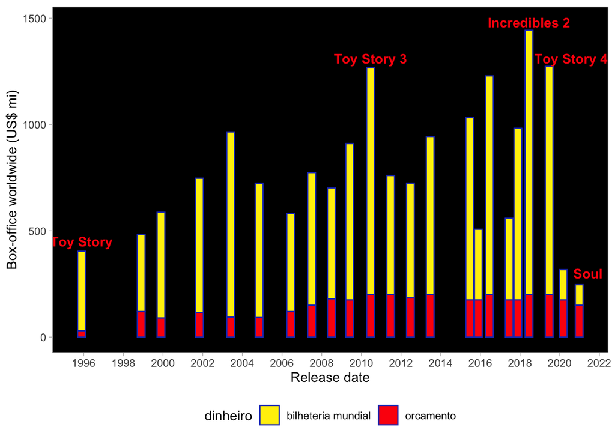

Como você pode ver acima, *Toy Story* nos conta uma história diferente dos outros filmes quando comparamos variáveis relacionadas ao dinheiro. Ele tem um orçamento muito pequeno e também uma bilheteria que está longe do grande desempenho alcançado pelos *blockbusters* mais importantes da Pixar. Talvez o público tivesse uma visão diferente do filme quando comparado aos pontos de vista dos críticos. Não tão rápido assim. Não sou especialista, mas talvez este fenômeno possa ser explicado pelo conjunto diferente de custos que estava implícito em fazer uma animação há 25 anos e até mesmo a inflação de todo este período pode influenciar o resultado final. Convido-os a fazer esta pesquisa.

Ao olhar para a linha do tempo, é notável como *Os incríveis 2, Toy Story 3, e Toy Story 4* tiveram bons desempenhos. Esses filmes foram as principais fontes de lucro para a Pixar. Infelizmente, o mesmo não pode ser dito sobre *Soul*. Ainda não o vi, mas a maioria dos meus amigos me disse que é um grande filme. A pandemia aqui talvez tenha, de alguma forma, uma enorme influência sobre estes resultados.

Como estamos falando de orçamento e bilheteria, uma pergunta que surge é: existe alguma relação que possamos descobrir quando vemos um gráfico de dispersão destas variáveis? Esta pergunta é respondida pela figura abaixo.

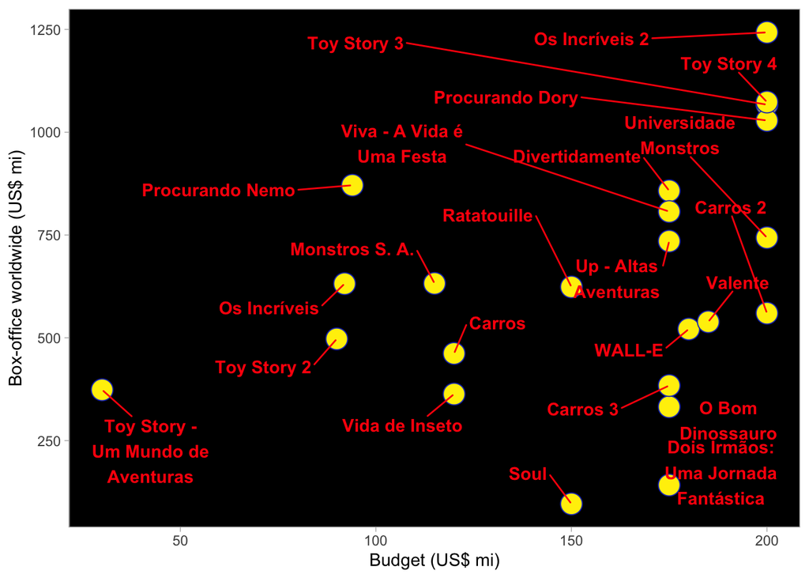

Outra relação que é uma boa idéia para testar é entre orçamento e média de notas do crítico. Junte-se a mim na análise.

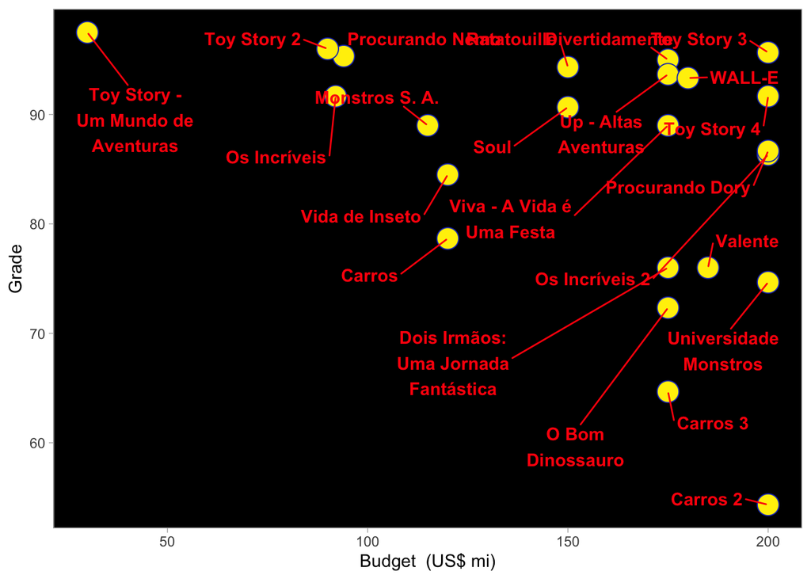

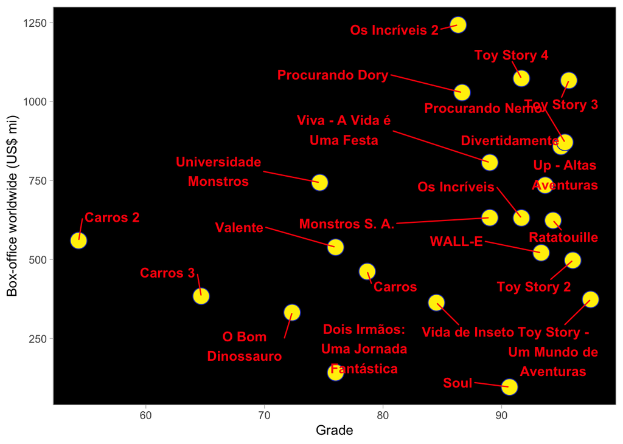

Em nossa última análise, parece estar claro que as avaliações críticas nem sempre coincidem com as avaliações do público, aqui representado pelas bilheterias alcançadas pelos filmes. Vemos que há casos de sucesso de crítica como *Soul* e *Toy Story 2*, mas com baixa receita. *Toy Story* está neste quadrante, mas como indicamos anteriormente, é difícil avaliá-lo como um relativo fracasso do público com base na receita do filme, já que se trata de dados de mais de duas décadas. Por outro lado, você vê que há coincidência na maioria dos outros filmes, especialmente no quadrante dos filmes com melhor classificação da crítica e desempenho de bilheteria. Para estes casos, *Toy Story 3, Toy Story 4* e *Procurando Nemo* parecem ser os melhores exemplos.

## Apenas continue a nadar

Chegamos agora ao final do texto. Vimos que as histórias contadas pela Pixar são parte de um conjunto de memórias compartilhadas por crianças, adolescentes, jovens e seus pais em várias partes do planeta. E até mesmo por aquela pessoas irritantes que escrevem sua opinião nos jornais (hey, isto é uma piada).

Para nós pais que estamos percebendo as fases de mudança na vida de nossos filhos que agora enfrentarão o mundo com outras possibilidades e experiências, vale a pena lembrar do cartaz de Procurando Nemo.

O mundo estará cheio de tubarões, medusas, e também Nemos, Dorys, baleias e tartarugas. No final do dia, o que parece ser mais importante é a famosa frase: continue a nadar.

## Créditos

Como não poderia ser de outra forma, devemos deixar os créditos dos filmes. Aqui a opção é utilizar os recursos de visualização de dados. Mostrarei abaixo os 23 profissionais que mais apareceram nessas pequenas letras no final dos filmes.

A Stanton, Docter, Lasseter e sua gangue, nossos muitos agradecimentos. Que mais animações venham para ficar em nossa memória afetiva. Continuem a nadar.

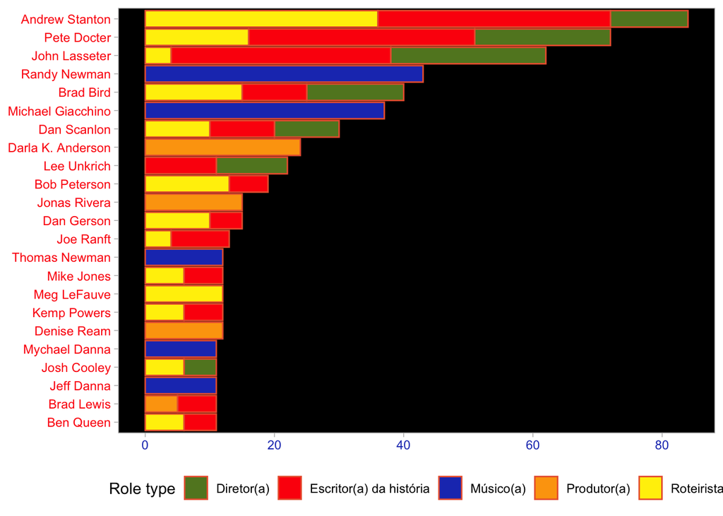

Gostaria também de creditar Eric Leung, o autor do pacote pixarfilms. Uma idéia certamente simples e ótima para a exploração de dados como esta.

## Código e Dados

O código e os dados estão disponíveis neste [gist](https://gist.github.com/fernandobarbalho/72137bd127d047ea0f293b3bd87d997d). Você pode me encontrar no [Twitter](https://twitter.com/barbalhofernand).